```python
# Required Packages
import pandas as pd
import numpy as np
import math
import json
import seaborn as sns
import matplotlib.pyplot as plt

from IPython.core.display import Image, display

from collections import defaultdict
person_off_trans = defaultdict(lambda: defaultdict(float))
import progressbar

from sklearn.model_selection import train_test_split
from sklearn.ensemble import RandomForestClassifier
from sklearn.multioutput import MultiOutputClassifier
from sklearn.metrics import classification_report, accuracy_score, f1_score, precision_score, recall_score

plt.style.use('ggplot')
%matplotlib inline
import warnings
warnings.filterwarnings("ignore")
```

[figure not shown]

```python
display(Image('https://upload.wikimedia.org/wikipedia/en/thumb/d/d3/Starbucks_Corporation_Logo_2011.svg/474px-Starbucks_Corporation_Logo_2011.svg.png',
              width=300, unconfined=True))
```

# Starbucks Offer Personalizations

In this article, simulated data that mimics customer behavior on the Starbucks rewards mobile app is used. Starbucks tends to send out offers to users of the mobile app once every few days. These offers are exclusive, that is not all users receive the same offer. An offer can contain a discount for their products or sometimes BOGO (buy one get one free). These offers have a validity period before the offer expires. The article here is inspired by a [towardsdatascience.com](https://towardsdatascience.com/using-starbucks-app-user-data-to-predict-effective-offers-20b799f3a6d5) article.

For preprocessing and initial data analysis see the first part of this article [here](https://hatefdastour.github.io/portfolio/machine_learning/Starbucks_Offer_Personalizations_Preprocessing_and_Analyzing.html).

- The Problem of Interest
- Effective Offers vs. Ineffective Offers
  - Effective Offers
  - Ineffective Offers
- Creating a General Dataframe

#### Loading the preprocessed data

```python
portfolio = pd.read_csv('Data/Clean_portfolio.csv')
profile = pd.read_csv('Data/Clean_profile.csv')
transcript = pd.read_csv('Data/Clean_transcript.csv')
transcript_portfolio = pd.read_csv('Data/Clean_transcript_portfolio.csv')
```

## The Problem of Interest

### Effective Offers vs. Ineffective Offers

#### Effective Offers

An offer is considered an effective offers if a customer receives an offer, and then view the received offer, and finally, complete a transaction either BOGO and Discount Offers, or complete a transaction using Informational Offers within the period those offers are valid.

#### Ineffective Offers

An offer is ineffective offers if it is not effective. However, this can be analyzed futher.

Consider the following diagram:

**Effective Offers**:

- Offer Received
  - Offer Viewed
    - Transaction
      - Offer Completed (BOGO and Discount Offers)
      - Offer Completed (Informational Offers - transactions must happen within the period those offers are valid)

**Ineffective Offers**:

- Offer Received
  - No Action Happend
    - no Transaction Happened
    - Offer not Viewed
  - Offer not Viewed
    - Offer not Viewed
      - Transaction
        - Offer Viewed
- Offer not Received
  - Transaction

The object of the exercise here is to predict the most suitable offer type that is needed to be sent out to each customer. In doing so, we need to combine the data (*Portfolio Data*, *Profile Data*, and *Transcript Data*) to build a general database that provides a summary of each user's transactional behaviors.

## Creating a General Dataframe

In this section, we create a general dataframe. First, let's introduce the new parameters (columns of our new dataframe). First, we can group the number of offers that a person received.

| New Parameters | Full Parameters name | Description |
| --- | --- | --- |
| BOGO_Offer_Rec | BOGO Offer Received | The number of BOGO offer received |
| Disc_Offer_Rec | Discount Offer Received | The number of Discoun offer received |
| Info_Offer_Rec | Informational Offer Received | The number of Informational offer received |

```python
temp = transcript_portfolio.loc[transcript_portfolio['event']=='offer received',:]
temp = temp.groupby('person').offer_type.value_counts().unstack()
user_data = pd.DataFrame(index = profile.id)
user_data = user_data.join(temp)
del temp
# renaming
user_data.rename(columns={'bogo':'BOGO_Offer_Rec',
                          'discount':'Disc_Offer_Rec',
                          'informational':'Info_Offer_Rec'},inplace=True)
user_data.head()
```

| id | BOGO_Offer_Rec | Disc_Offer_Rec | Info_Offer_Rec |
| --- | --- | --- | --- |
| 68be06ca386d4c31939f3a4f0e3dd783 | NaN | 5.0 | NaN |
| 0610b486422d4921ae7d2bf64640c50b | 1.0 | NaN | 1.0 |
| 38fe809add3b4fcf9315a9694bb96ff5 | 1.0 | NaN | 1.0 |
| 78afa995795e4d85b5d9ceeca43f5fef | 3.0 | NaN | 1.0 |
| a03223e636434f42ac4c3df47e8bac43 | NaN | 3.0 | 2.0 |

As can be seen, not all customers received all offers. Let's investigate this a bit further. Since we have three columns, if we have **NaN** greater than 2, then it means that the customers haven't received any offers!

```python
no_offer = user_data.isnull().sum(axis=1)
# Creating a list
no_offer_list=list(no_offer[no_offer>2].index)
# Print
print ('users never received any offers = %i' % no_offer[no_offer>2].count())
```

```
users never received any offers = 6
```

We can see that **six** users never received any offers!

We can test the results. For example, for the first user from **no_offer_list**, we have

```python
transcript_portfolio.loc[transcript_portfolio.person ==no_offer_list[0],:]
```

|  | person | event | time | amount | reward_received | offer_id | reward_defined | difficulty | duration | offer_type | email | mobile | social | web |
| --- | --- | --- | --- | --- | --- | --- | --- | --- | --- | --- | --- | --- | --- | --- |
| 69477 | c6e579c6821c41d1a7a6a9cf936e91bb | transaction | 174 | 0.65 | NaN | NaN | NaN | NaN | NaN | NaN | NaN | NaN | NaN | NaN |
| 87239 | c6e579c6821c41d1a7a6a9cf936e91bb | transaction | 222 | 1.91 | NaN | NaN | NaN | NaN | NaN | NaN | NaN | NaN | NaN | NaN |
| 163610 | c6e579c6821c41d1a7a6a9cf936e91bb | transaction | 408 | 1.25 | NaN | NaN | NaN | NaN | NaN | NaN | NaN | NaN | NaN | NaN |
| 243317 | c6e579c6821c41d1a7a6a9cf936e91bb | transaction | 570 | 3.14 | NaN | NaN | NaN | NaN | NaN | NaN | NaN | NaN | NaN | NaN |

It can be seen that the customer (person column) has all **NaN** columns!

Adding more columns to **user_data** dataframe, we can introduce new parameters.

[output not shown]

```python
# Total Transaction Count (Tot_Tran_Cnt)
Tot_Tran_Cnt = transcript_portfolio.loc[transcript_portfolio.event=='transaction',:].groupby('person').event.count()
user_data = user_data.join(Tot_Tran_Cnt)
del Tot_Tran_Cnt
user_data = user_data.rename(columns={'event':'Tot_Tran_Cnt'})
# Total Transaction Amount (Tot_Tran_Amnt)
Tot_Tran_Amnt = transcript_portfolio.loc[transcript_portfolio.event=='transaction',:].groupby('person').amount.sum()
user_data = user_data.join(Tot_Tran_Amnt)
del Tot_Tran_Amnt
user_data = user_data.rename(columns={'amount':'Tot_Tran_Amnt'})
# Total Rewards Received (Tot_Rewards_Rec)
Tot_Rewards_Rec = transcript_portfolio.groupby('person').reward_received.sum()
user_data= user_data.join(Tot_Rewards_Rec)
del Tot_Rewards_Rec
user_data = user_data.rename(columns={'reward_received':'Tot_Rewards_Rec'})
# Average Transaction Amount (Ave_Tran_Amnt)
user_data['Ave_Tran_Amnt'] = round(user_data.Tot_Tran_Amnt/user_data.Tot_Tran_Cnt,3)
#user_data.sort_values(by='Ave_Tran_Amnt', ascending=False)
user_data.head()
```

| id | BOGO_Offer_Rec | Disc_Offer_Rec | Info_Offer_Rec | Tot_Tran_Cnt | Tot_Tran_Amnt | Tot_Rewards_Rec | Ave_Tran_Amnt |
| --- | --- | --- | --- | --- | --- | --- | --- |
| 68be06ca386d4c31939f3a4f0e3dd783 | NaN | 5.0 | NaN | 9.0 | 20.40 | 5.0 | 2.267 |
| 0610b486422d4921ae7d2bf64640c50b | 1.0 | NaN | 1.0 | 3.0 | 77.01 | 5.0 | 25.670 |
| 38fe809add3b4fcf9315a9694bb96ff5 | 1.0 | NaN | 1.0 | 6.0 | 14.30 | 0.0 | 2.383 |
| 78afa995795e4d85b5d9ceeca43f5fef | 3.0 | NaN | 1.0 | 7.0 | 159.27 | 20.0 | 22.753 |
| a03223e636434f42ac4c3df47e8bac43 | NaN | 3.0 | 2.0 | 3.0 | 4.65 | 0.0 | 1.550 |

Now we add more parameters to the **user_data** dataframe.

| New Parameters | Full Parameters name | Description |
| --- | --- | --- |
| Tran_Comp_NO_off | Transactions Count without any Offers | The number of transactions for a user completes without an offer |
| Tran_Comp_off | Transactions Count with Offers | The number of transactions for a user completes with an offer |
| Tran_Amnt_NO_off | Transactions Amount without any Offers | The amount of transactions for a user completes without an offer |
| Tran_Amnt_off | Transactions Amount with Offers | The amount of transactions for a user completes with an offer |
| Offer_Tran_Cnt_Ratio | Offer Transactions Count Ratio | Transaction count incentivized by offer / Total number of transactions - TC_Of/TTC |
| Offer_Tran_Amnt_Ratio | Offer Transactions Amount Ratio | Transaction amount incentivized by offer / Total amount of transactions - TA_Of/TTA |
| Offer_Comp_View_Ratio | Offer Completed View Ratio | The number of offer completed / the number of offer viewed |
| Offer_Comp_Rec_Ratio | Offer Completed Receive Ratio | The number of offers completed/ the number of offers received |
| Tran_Amnt_per_Offer | Transactions Amount per Offer | The total transaction amount with offer/ Total number of transactions with an offer |
| Reward_per_Offer | Reward per Offer | Total rewards received / the number of offer completed |
| BOGO_Comp | BOGO Completed | The number of offer completed for BOGO offer after viewing the BOGO offer |
| Disc_Comp | Discount Completed | The number of offer completed for Discount offer after viewing the Discount offer |
| Info_Comp | Information Completed | The number of offer completed for Information offer after viewing the Information offer |
| BOGO_Conv | BOGO offer conversion rate | The number of BOGO offers completed / The number of BOGO offer received - BOGO_Comp/BOGO_OR |
| Info_Conv | Information offer conversion rate | The number of Information offers completed / The number of Information offer received - Info_Comp/Info_OR |
| Disc_Conv | Discount offer conversion rate | The number of Discount offers completed / The number of Discount offer received - Disc_Comp/Disc_OR |

Given the fact that **there is no explicit offer conversion** for the parameters that just being introduced. We need to use **nested loops** based on `offer completion count` and `transactions amount from the offer conversion`

We can create a function that takes a user_id and gives all user records as a DataFrame.

```python
user_record = lambda user_id: transcript_portfolio.loc[transcript_portfolio['person'] == user_id,:].reset_index(drop=True)
# For example we can run:
# user_record('68be06ca386d4c31939f3a4f0e3dd783')
# to get all records of '68be06ca386d4c31939f3a4f0e3dd783'
```

```python
# creating a dictionary list
person_effective_offer = defaultdict(list)
# creating a list of 'offer_id' for only 'bogo' and 'discount' offer types
bogo_discount_offer_ids = portfolio[portfolio['offer_type'].isin(['bogo', 'discount'])]['offer_id'].values
```

```python
# initial value for Counter
Counter = 0
Progress_Bar = progressbar.ProgressBar(maxval=user_data.shape[0],
                                       widgets=[progressbar.Bar('*', '[', ']'),
                                                progressbar.Percentage()])
# Starting the Progress Bar
Progress_Bar.start()

# The outer loop for ALL users in the user_data
for user_id in user_data.index:

    Counter+=1
    Progress_Bar.update(Counter)
    # getting the records for the current user
    Transaction_Received = user_record(user_id)
    # The index of the received offers
    offer_received_index = Transaction_Received[Transaction_Received['event'] == 'offer received'].index.values
    # All transactions for the current user
    transactions = Transaction_Received[Transaction_Received.event == 'transaction']
    # Transaction offer index set
    Transaction_Offer_Index = []
    # The iner loop for the received offers indeces
    for r_i in offer_received_index:
        # offer id corresponding to the index
        offer_id = Transaction_Received.loc[r_i, 'offer_id']
        # offer validity time (in hours)
        offer_valid_for = int(portfolio[portfolio['offer_id'] == offer_id]['duration']) * 24
        # offer start time
        offer_start = Transaction_Received.loc[r_i, 'time']
        # offer end time () = offer start time + offer validity time
        offer_end = offer_start + offer_valid_for
        # viewed offers
        viewed = Transaction_Received[(Transaction_Received['offer_id'] == offer_id) &
                           (Transaction_Received['event'] == 'offer viewed') &
                           (Transaction_Received['time'] >= offer_start) &
                           (Transaction_Received['time'] <= offer_end)]
        # only if "viewed offers" is not zero
        if viewed.shape[0] >0 :
            person_off_trans[user_id]['Offer_View'] += 1
            if offer_id in bogo_discount_offer_ids:
                # checking whether a viewed offer has been completed
                completed = Transaction_Received[(Transaction_Received['offer_id'] == offer_id) &
                           (Transaction_Received['event'] == 'offer completed') &
                           (Transaction_Received['time'] >= offer_start) &
                           (Transaction_Received['time'] <= offer_end)]
                # only if "completed offers" is not zero
                if completed.shape[0] > 0 :
                    view_ind = viewed.index[0]
                    comp_ind = completed.index[0]
                    conv_offer_type = completed['offer_type'].values[0]
                    Offer_Difficulty = completed['difficulty'].values[0]

                    if view_ind < comp_ind:
                        person_off_trans[user_id]['offer_comp'] += 1
                        person_off_trans[user_id][conv_offer_type] += 1
                        bogo_disc_trans = transactions.loc[view_ind:comp_ind].amount.sum()
                        person_off_trans[user_id]['Offer_Trans_Amnt'] += bogo_disc_trans
                        person_off_trans[user_id]['Offer_Difficulty'] += Offer_Difficulty

                        if offer_id not in person_effective_offer[user_id]:
                            person_effective_offer[user_id].append(offer_id)

            else:
                view_time = viewed.iloc[0]['time']
                person_off_trans[user_id]['Offer_View'] += 1
                info_trans = Transaction_Received[(Transaction_Received['event'] == 'transaction') &
                                       (Transaction_Received['time'] >= view_time) &
                                       (Transaction_Received['time'] <= offer_end)]
                if info_trans.shape[0] > 0:
                    person_off_trans[user_id]['offer_comp'] += 1
                    info_tran_amt = info_trans['amount'].sum()
                    person_off_trans[user_id]['Offer_Trans_Amnt'] += info_tran_amt
                    person_off_trans[user_id]['Informational'] +=1
                    if offer_id not in person_effective_offer[user_id]:
                        person_effective_offer[user_id].append(offer_id)
# End of the seraching process
```

```
[*************************************************************************]100%
```

Once the searching process has been completed, we can convert the output to a data frame.

```python
# convert the dictionary into dataframe
person_off_trans_df = pd.DataFrame.from_dict(person_off_trans, orient = 'index')
# saving as a CSV file
#export_csv = person_off_trans_df.to_csv (r'Data\person_off_trans.csv', header=True)
person_off_trans_df.head()
```

|  | Offer_View | offer_comp | discount | Offer_Trans_Amnt | Offer_Difficulty | bogo | Informational |
| --- | --- | --- | --- | --- | --- | --- | --- |
| 68be06ca386d4c31939f3a4f0e3dd783 | 5.0 | 2.0 | 2.0 | 17.71 | 17.0 | NaN | NaN |
| 38fe809add3b4fcf9315a9694bb96ff5 | 1.0 | NaN | NaN | NaN | NaN | NaN | NaN |
| 78afa995795e4d85b5d9ceeca43f5fef | 5.0 | 3.0 | NaN | 91.00 | 15.0 | 2.0 | 1.0 |
| a03223e636434f42ac4c3df47e8bac43 | 5.0 | NaN | NaN | NaN | NaN | NaN | NaN |
| e2127556f4f64592b11af22de27a7932 | 3.0 | 2.0 | 1.0 | 36.84 | 15.0 | 1.0 | NaN |

The size of the output dataframe:

```python
person_off_trans_df.shape
```

```
(16793, 7)
```

```python
# comp stands for completed!
person_off_trans_df = person_off_trans_df.rename(columns={'bogo':'BOGO_comp',
                                                          'discount':'Disc_comp',
                                                          'Informational':'Info_comp'})
person_off_trans_df.head()
```

|  | Offer_View | offer_comp | Disc_comp | Offer_Trans_Amnt | Offer_Difficulty | BOGO_comp | Info_comp |
| --- | --- | --- | --- | --- | --- | --- | --- |
| 68be06ca386d4c31939f3a4f0e3dd783 | 5.0 | 2.0 | 2.0 | 17.71 | 17.0 | NaN | NaN |
| 38fe809add3b4fcf9315a9694bb96ff5 | 1.0 | NaN | NaN | NaN | NaN | NaN | NaN |
| 78afa995795e4d85b5d9ceeca43f5fef | 5.0 | 3.0 | NaN | 91.00 | 15.0 | 2.0 | 1.0 |
| a03223e636434f42ac4c3df47e8bac43 | 5.0 | NaN | NaN | NaN | NaN | NaN | NaN |
| e2127556f4f64592b11af22de27a7932 | 3.0 | 2.0 | 1.0 | 36.84 | 15.0 | 1.0 | NaN |

Now, turning all **NaN** values in 'bogo_offer', 'discount_offer' and 'information_offer' into zero and ones. One if the value is not not **NaN** and zero for **NaN** values.

```python
person_off_trans_df['BOGO_offer'] = person_off_trans_df['BOGO_comp'].apply(lambda x: 0 if np.isnan(x) else 1)
person_off_trans_df['Disc_offer'] = person_off_trans_df['Disc_comp'].apply(lambda x: 0 if np.isnan(x) else 1)
person_off_trans_df['Info_offer'] = person_off_trans_df['Info_comp'].apply(lambda x: 0 if np.isnan(x) else 1)
person_off_trans_df.head()
```

|  | Offer_View | offer_comp | Disc_comp | Offer_Trans_Amnt | Offer_Difficulty | BOGO_comp | Info_comp | BOGO_offer | Disc_offer | Info_offer |
| --- | --- | --- | --- | --- | --- | --- | --- | --- | --- | --- |
| 68be06ca386d4c31939f3a4f0e3dd783 | 5.0 | 2.0 | 2.0 | 17.71 | 17.0 | NaN | NaN | 0 | 1 | 0 |
| 38fe809add3b4fcf9315a9694bb96ff5 | 1.0 | NaN | NaN | NaN | NaN | NaN | NaN | 0 | 0 | 0 |
| 78afa995795e4d85b5d9ceeca43f5fef | 5.0 | 3.0 | NaN | 91.00 | 15.0 | 2.0 | 1.0 | 1 | 0 | 1 |
| a03223e636434f42ac4c3df47e8bac43 | 5.0 | NaN | NaN | NaN | NaN | NaN | NaN | 0 | 0 | 0 |
| e2127556f4f64592b11af22de27a7932 | 3.0 | 2.0 | 1.0 | 36.84 | 15.0 | 1.0 | NaN | 1 | 1 | 0 |

Merging the current dataframe, `person_off_trans_df`, with the `user_data` dataframe.

```python
user_data_new = user_data.join(person_off_trans_df)
user_data_new.head()
```

| id | BOGO_Offer_Rec | Disc_Offer_Rec | Info_Offer_Rec | Tot_Tran_Cnt | Tot_Tran_Amnt | Tot_Rewards_Rec | Ave_Tran_Amnt | Offer_View | offer_comp | Disc_comp | Offer_Trans_Amnt | Offer_Difficulty | BOGO_comp | Info_comp | BOGO_offer | Disc_offer | Info_offer |
| --- | --- | --- | --- | --- | --- | --- | --- | --- | --- | --- | --- | --- | --- | --- | --- | --- | --- |
| 68be06ca386d4c31939f3a4f0e3dd783 | NaN | 5.0 | NaN | 9.0 | 20.40 | 5.0 | 2.267 | 5.0 | 2.0 | 2.0 | 17.71 | 17.0 | NaN | NaN | 0.0 | 1.0 | 0.0 |
| 0610b486422d4921ae7d2bf64640c50b | 1.0 | NaN | 1.0 | 3.0 | 77.01 | 5.0 | 25.670 | NaN | NaN | NaN | NaN | NaN | NaN | NaN | NaN | NaN | NaN |
| 38fe809add3b4fcf9315a9694bb96ff5 | 1.0 | NaN | 1.0 | 6.0 | 14.30 | 0.0 | 2.383 | 1.0 | NaN | NaN | NaN | NaN | NaN | NaN | 0.0 | 0.0 | 0.0 |
| 78afa995795e4d85b5d9ceeca43f5fef | 3.0 | NaN | 1.0 | 7.0 | 159.27 | 20.0 | 22.753 | 5.0 | 3.0 | NaN | 91.00 | 15.0 | 2.0 | 1.0 | 1.0 | 0.0 | 1.0 |
| a03223e636434f42ac4c3df47e8bac43 | NaN | 3.0 | 2.0 | 3.0 | 4.65 | 0.0 | 1.550 | 5.0 | NaN | NaN | NaN | NaN | NaN | NaN | 0.0 | 0.0 | 0.0 |

```python
# if all 3 offers are 0, then flag "No_Offer" col as 1 else 0
user_data_new['No_Offer'] = np.where(user_data_new['offer_comp'].isnull(), 1, 0)
print('transaction only customers : {}'.format(user_data_new['No_Offer'].sum()))
```

```
transaction only customers : 4030
```

```python
user_data_new.loc[user_data_new['No_Offer']==1,:].head()
```

| id | BOGO_Offer_Rec | Disc_Offer_Rec | Info_Offer_Rec | Tot_Tran_Cnt | Tot_Tran_Amnt | Tot_Rewards_Rec | Ave_Tran_Amnt | Offer_View | offer_comp | Disc_comp | Offer_Trans_Amnt | Offer_Difficulty | BOGO_comp | Info_comp | BOGO_offer | Disc_offer | Info_offer | No_Offer |
| --- | --- | --- | --- | --- | --- | --- | --- | --- | --- | --- | --- | --- | --- | --- | --- | --- | --- | --- |
| 0610b486422d4921ae7d2bf64640c50b | 1.0 | NaN | 1.0 | 3.0 | 77.01 | 5.0 | 25.670 | NaN | NaN | NaN | NaN | NaN | NaN | NaN | NaN | NaN | NaN | 1 |
| 38fe809add3b4fcf9315a9694bb96ff5 | 1.0 | NaN | 1.0 | 6.0 | 14.30 | 0.0 | 2.383 | 1.0 | NaN | NaN | NaN | NaN | NaN | NaN | 0.0 | 0.0 | 0.0 | 1 |
| a03223e636434f42ac4c3df47e8bac43 | NaN | 3.0 | 2.0 | 3.0 | 4.65 | 0.0 | 1.550 | 5.0 | NaN | NaN | NaN | NaN | NaN | NaN | 0.0 | 0.0 | 0.0 | 1 |
| 8ec6ce2a7e7949b1bf142def7d0e0586 | 1.0 | 3.0 | 1.0 | NaN | NaN | 0.0 | NaN | 6.0 | NaN | NaN | NaN | NaN | NaN | NaN | 0.0 | 0.0 | 0.0 | 1 |
| 68617ca6246f4fbc85e91a2a49552598 | 3.0 | 2.0 | NaN | 2.0 | 0.24 | 0.0 | 0.120 | 4.0 | NaN | NaN | NaN | NaN | NaN | NaN | 0.0 | 0.0 | 0.0 | 1 |

```python
user_data_new['Offer_Tran_Cnt_Ratio'] = round(user_data_new['offer_comp']/ user_data_new['Tot_Tran_Cnt'],2)
user_data_new['Offer_Trans_Amnt'] = np.where(user_data_new['Offer_Trans_Amnt']>user_data_new['Tot_Tran_Amnt'],
                                             user_data_new['Tot_Tran_Amnt'], user_data_new['Offer_Trans_Amnt'])
user_data_new['Offer_Trans_Amnt_Ratio'] = round(user_data_new['Offer_Trans_Amnt']/ user_data_new['Tot_Tran_Amnt'],2)
user_data_new['Offer_Comp_View_Ratio'] = user_data_new['offer_comp']/ user_data_new['Offer_View']
user_data_new['Offer_Comp_Rec_Ratio'] = user_data_new['offer_comp']/ user_data_new[['BOGO_Offer_Rec','Disc_Offer_Rec',
                                                                                    'Info_Offer_Rec']].sum(axis=1)
user_data_new['Tran_Amnt_per_Offer'] = round(user_data_new['Offer_Trans_Amnt']/ user_data_new['offer_comp'],2)
user_data_new['Reward_per_Offer'] = round(user_data_new['Tot_Rewards_Rec']/ user_data_new['offer_comp'],2)
user_data_new['Difficulty_per_Offer'] = round(user_data_new['Offer_Difficulty']/ user_data_new['offer_comp'],2)
```

```python
user_data_new.head()
```

| id | BOGO_Offer_Rec | Disc_Offer_Rec | Info_Offer_Rec | Tot_Tran_Cnt | Tot_Tran_Amnt | Tot_Rewards_Rec | Ave_Tran_Amnt | Offer_View | offer_comp | Disc_comp | ... | Disc_offer | Info_offer | No_Offer | Offer_Tran_Cnt_Ratio | Offer_Trans_Amnt_Ratio | Offer_Comp_View_Ratio | Offer_Comp_Rec_Ratio | Tran_Amnt_per_Offer | Reward_per_Offer | Difficulty_per_Offer |
| --- | --- | --- | --- | --- | --- | --- | --- | --- | --- | --- | --- | --- | --- | --- | --- | --- | --- | --- | --- | --- | --- |
| 68be06ca386d4c31939f3a4f0e3dd783 | NaN | 5.0 | NaN | 9.0 | 20.40 | 5.0 | 2.267 | 5.0 | 2.0 | 2.0 | ... | 1.0 | 0.0 | 0 | 0.22 | 0.87 | 0.4 | 0.40 | 8.86 | 2.50 | 8.5 |
| 0610b486422d4921ae7d2bf64640c50b | 1.0 | NaN | 1.0 | 3.0 | 77.01 | 5.0 | 25.670 | NaN | NaN | NaN | ... | NaN | NaN | 1 | NaN | NaN | NaN | NaN | NaN | NaN | NaN |
| 38fe809add3b4fcf9315a9694bb96ff5 | 1.0 | NaN | 1.0 | 6.0 | 14.30 | 0.0 | 2.383 | 1.0 | NaN | NaN | ... | 0.0 | 0.0 | 1 | NaN | NaN | NaN | NaN | NaN | NaN | NaN |
| 78afa995795e4d85b5d9ceeca43f5fef | 3.0 | NaN | 1.0 | 7.0 | 159.27 | 20.0 | 22.753 | 5.0 | 3.0 | NaN | ... | 0.0 | 1.0 | 0 | 0.43 | 0.57 | 0.6 | 0.75 | 30.33 | 6.67 | 5.0 |
| a03223e636434f42ac4c3df47e8bac43 | NaN | 3.0 | 2.0 | 3.0 | 4.65 | 0.0 | 1.550 | 5.0 | NaN | NaN | ... | 0.0 | 0.0 | 1 | NaN | NaN | NaN | NaN | NaN | NaN | NaN |

5 rows × 25 columns

```python
# sometimes people receive rewards without actually completing an offer, those are rare cases but still need to corrected
user_data_new['Tot_Rewards_Rec'] = np.where(user_data_new['offer_comp']==0, 0 , user_data_new['Tot_Rewards_Rec'] )
user_data_new['Reward_per_Offer'] = np.where(user_data_new['offer_comp']==0, 0 , user_data_new['Reward_per_Offer'] )
user_data_new.fillna(0, inplace=True)
user_data_new.head()
```

| id | BOGO_Offer_Rec | Disc_Offer_Rec | Info_Offer_Rec | Tot_Tran_Cnt | Tot_Tran_Amnt | Tot_Rewards_Rec | Ave_Tran_Amnt | Offer_View | offer_comp | Disc_comp | ... | Disc_offer | Info_offer | No_Offer | Offer_Tran_Cnt_Ratio | Offer_Trans_Amnt_Ratio | Offer_Comp_View_Ratio | Offer_Comp_Rec_Ratio | Tran_Amnt_per_Offer | Reward_per_Offer | Difficulty_per_Offer |
| --- | --- | --- | --- | --- | --- | --- | --- | --- | --- | --- | --- | --- | --- | --- | --- | --- | --- | --- | --- | --- | --- |
| 68be06ca386d4c31939f3a4f0e3dd783 | 0.0 | 5.0 | 0.0 | 9.0 | 20.40 | 5.0 | 2.267 | 5.0 | 2.0 | 2.0 | ... | 1.0 | 0.0 | 0 | 0.22 | 0.87 | 0.4 | 0.40 | 8.86 | 2.50 | 8.5 |
| 0610b486422d4921ae7d2bf64640c50b | 1.0 | 0.0 | 1.0 | 3.0 | 77.01 | 5.0 | 25.670 | 0.0 | 0.0 | 0.0 | ... | 0.0 | 0.0 | 1 | 0.00 | 0.00 | 0.0 | 0.00 | 0.00 | 0.00 | 0.0 |
| 38fe809add3b4fcf9315a9694bb96ff5 | 1.0 | 0.0 | 1.0 | 6.0 | 14.30 | 0.0 | 2.383 | 1.0 | 0.0 | 0.0 | ... | 0.0 | 0.0 | 1 | 0.00 | 0.00 | 0.0 | 0.00 | 0.00 | 0.00 | 0.0 |
| 78afa995795e4d85b5d9ceeca43f5fef | 3.0 | 0.0 | 1.0 | 7.0 | 159.27 | 20.0 | 22.753 | 5.0 | 3.0 | 0.0 | ... | 0.0 | 1.0 | 0 | 0.43 | 0.57 | 0.6 | 0.75 | 30.33 | 6.67 | 5.0 |
| a03223e636434f42ac4c3df47e8bac43 | 0.0 | 3.0 | 2.0 | 3.0 | 4.65 | 0.0 | 1.550 | 5.0 | 0.0 | 0.0 | ... | 0.0 | 0.0 | 1 | 0.00 | 0.00 | 0.0 | 0.00 | 0.00 | 0.00 | 0.0 |

5 rows × 25 columns

Merging `user_data` with `profile` data to get demographics features for each customer

```python
profile.head()
```

|  | gender | age | id | became_member_on | income | member_since_year | member_tenure |
| --- | --- | --- | --- | --- | --- | --- | --- |
| 0 | NaN | 55.0 | 68be06ca386d4c31939f3a4f0e3dd783 | 2017-02-12 | 64000.0 | 2017 | 23.0 |
| 1 | F | 55.0 | 0610b486422d4921ae7d2bf64640c50b | 2017-07-15 | 112000.0 | 2017 | 18.0 |
| 2 | NaN | 55.0 | 38fe809add3b4fcf9315a9694bb96ff5 | 2018-07-12 | 64000.0 | 2018 | 6.0 |
| 3 | F | 75.0 | 78afa995795e4d85b5d9ceeca43f5fef | 2017-05-09 | 100000.0 | 2017 | 20.0 |
| 4 | NaN | 55.0 | a03223e636434f42ac4c3df47e8bac43 | 2017-08-04 | 64000.0 | 2017 | 17.0 |

```python
profile.isnull().sum()
```

```
gender               2175
age                     0
id                      0
became_member_on        0
income                  0
member_since_year       0
member_tenure           0
dtype: int64
```

```python
profile.income.fillna(profile.income.median(), inplace=True)
profile_dummy = pd.get_dummies(profile, columns=['gender'])
profile_dummy.index = profile_dummy.id
profile_dummy.drop(['became_member_on','member_since_year','id'],axis=1, inplace=True)
profile_dummy.head()
```

| id | age | income | member_tenure | gender_F | gender_M | gender_O |
| --- | --- | --- | --- | --- | --- | --- |
| 68be06ca386d4c31939f3a4f0e3dd783 | 55.0 | 64000.0 | 23.0 | 0 | 0 | 0 |
| 0610b486422d4921ae7d2bf64640c50b | 55.0 | 112000.0 | 18.0 | 1 | 0 | 0 |
| 38fe809add3b4fcf9315a9694bb96ff5 | 55.0 | 64000.0 | 6.0 | 0 | 0 | 0 |
| 78afa995795e4d85b5d9ceeca43f5fef | 75.0 | 100000.0 | 20.0 | 1 | 0 | 0 |
| a03223e636434f42ac4c3df47e8bac43 | 55.0 | 64000.0 | 17.0 | 0 | 0 | 0 |

```python
#finalize the features by joining the two dataframes
user_data_final = user_data_new.join(profile_dummy)
user_data_final.head()
```

| id | BOGO_Offer_Rec | Disc_Offer_Rec | Info_Offer_Rec | Tot_Tran_Cnt | Tot_Tran_Amnt | Tot_Rewards_Rec | Ave_Tran_Amnt | Offer_View | offer_comp | Disc_comp | ... | Offer_Comp_Rec_Ratio | Tran_Amnt_per_Offer | Reward_per_Offer | Difficulty_per_Offer | age | income | member_tenure | gender_F | gender_M | gender_O |
| --- | --- | --- | --- | --- | --- | --- | --- | --- | --- | --- | --- | --- | --- | --- | --- | --- | --- | --- | --- | --- | --- |
| 68be06ca386d4c31939f3a4f0e3dd783 | 0.0 | 5.0 | 0.0 | 9.0 | 20.40 | 5.0 | 2.267 | 5.0 | 2.0 | 2.0 | ... | 0.40 | 8.86 | 2.50 | 8.5 | 55.0 | 64000.0 | 23.0 | 0 | 0 | 0 |
| 0610b486422d4921ae7d2bf64640c50b | 1.0 | 0.0 | 1.0 | 3.0 | 77.01 | 5.0 | 25.670 | 0.0 | 0.0 | 0.0 | ... | 0.00 | 0.00 | 0.00 | 0.0 | 55.0 | 112000.0 | 18.0 | 1 | 0 | 0 |
| 38fe809add3b4fcf9315a9694bb96ff5 | 1.0 | 0.0 | 1.0 | 6.0 | 14.30 | 0.0 | 2.383 | 1.0 | 0.0 | 0.0 | ... | 0.00 | 0.00 | 0.00 | 0.0 | 55.0 | 64000.0 | 6.0 | 0 | 0 | 0 |
| 78afa995795e4d85b5d9ceeca43f5fef | 3.0 | 0.0 | 1.0 | 7.0 | 159.27 | 20.0 | 22.753 | 5.0 | 3.0 | 0.0 | ... | 0.75 | 30.33 | 6.67 | 5.0 | 75.0 | 100000.0 | 20.0 | 1 | 0 | 0 |
| a03223e636434f42ac4c3df47e8bac43 | 0.0 | 3.0 | 2.0 | 3.0 | 4.65 | 0.0 | 1.550 | 5.0 | 0.0 | 0.0 | ... | 0.00 | 0.00 | 0.00 | 0.0 | 55.0 | 64000.0 | 17.0 | 0 | 0 | 0 |

5 rows × 31 columns

## Machine Learning

##### Multioutput Classification Model to determine the best offer type

The model will use the 3 offer types as 3 target variables to find the offer type with the highest probability of conversion to send to each customer. And since there is more than one output, there is limited choice of classifiers that support multioutput - decision tree family in general all support multioutput models.

I will choose Random Forest for the following reasons:

- Data samples for each tree are selected using bootstrapping and only a random subset of the features are used at each node to decide on best split that maximize the information gain. The randomization in the feature and data sample selection can siginificantly reduce model variance thus less prone to overfitting. This is the biggest advantages of random forest over the decision tree model.
- A group of trees are built in parallel and final decision of the classification of each data point is based on majority voting. This process provides a better estimate of the feature importances - the averaged impurity decrease computed from all decision trees in the forest.
- It does not assume a linear relationship between the target variable and the features, make it more flexible in identifying the class boundries. Also tree models do not need much feature preprocessing such as standardization or normalization before running the model.

```python
X = user_data_final.drop(['BOGO_offer','Disc_offer','Info_offer','No_Offer',
                        'BOGO_comp','Info_comp','Disc_comp','Tot_Rewards_Rec','Offer_Difficulty'], axis=1)
Y = user_data_final[['BOGO_offer','Disc_offer','Info_offer']]

x_train, x_test, y_train, y_test = train_test_split(X, Y, test_size = 0.2)

clf = MultiOutputClassifier(RandomForestClassifier(n_estimators=100, oob_score=True))

clf.fit(x_train, y_train)
```

```
MultiOutputClassifier(estimator=RandomForestClassifier(bootstrap=True,
                                                       class_weight=None,
                                                       criterion='gini',
                                                       max_depth=None,
                                                       max_features='auto',
                                                       max_leaf_nodes=None,
                                                       min_impurity_decrease=0.0,
                                                       min_impurity_split=None,
                                                       min_samples_leaf=1,
                                                       min_samples_split=2,
                                                       min_weight_fraction_leaf=0.0,
                                                       n_estimators=100,
                                                       n_jobs=None,
                                                       oob_score=True,
                                                       random_state=None,
                                                       verbose=0,
                                                       warm_start=False),
                      n_jobs=None)
```

```python
def build_report(y_test,y_pred, avg_param):

    # build classification report on every target variables
    performances = []
    for i in range(len(Y.columns)):
        performances.append([f1_score(y_test.values[:, i], y_pred[:, i], average= avg_param),
                             precision_score(y_test.values[:, i], y_pred[:, i], average= avg_param),
                             recall_score(y_test.values[:, i], y_pred[:, i], average= avg_param)])
    # build dataframe
    performances = pd.DataFrame(performances, columns=['f1 score', 'precision', 'recall'],
                                index = Y.columns)
    return performances
```

```python
y_pred = clf.predict(x_test)
weighted_perform = build_report(y_test,y_pred,avg_param = 'weighted')
weighted_perform
```

|  | f1 score | precision | recall |
| --- | --- | --- | --- |
| BOGO_offer | 0.951332 | 0.953862 | 0.951176 |
| Disc_offer | 0.968213 | 0.968516 | 0.968235 |
| Info_offer | 0.979687 | 0.979677 | 0.979706 |

```python
for i in range(3):
    print(classification_report(y_test.values[:,i], y_pred[:,i]))
```

```
              precision    recall  f1-score   support

         0.0       0.99      0.93      0.96      1912
         1.0       0.91      0.98      0.95      1488

    accuracy                           0.95      3400
   macro avg       0.95      0.95      0.95      3400
weighted avg       0.95      0.95      0.95      3400

              precision    recall  f1-score   support

         0.0       0.98      0.95      0.97      1630
         1.0       0.96      0.98      0.97      1770

    accuracy                           0.97      3400
   macro avg       0.97      0.97      0.97      3400
weighted avg       0.97      0.97      0.97      3400

              precision    recall  f1-score   support

         0.0       0.98      0.99      0.99      2359
         1.0       0.97      0.96      0.97      1041

    accuracy                           0.98      3400
   macro avg       0.98      0.98      0.98      3400
weighted avg       0.98      0.98      0.98      3400
```

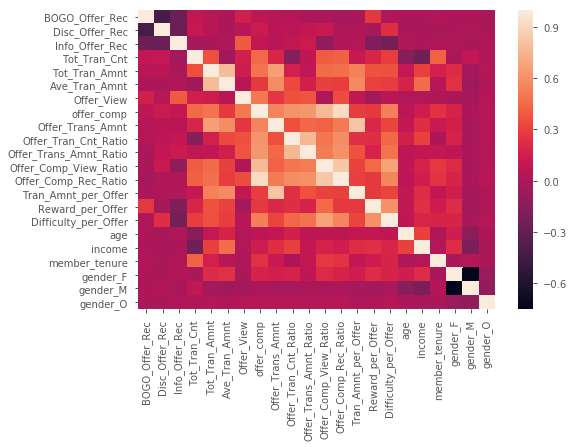

```python
plt.style.use('seaborn-notebook')
sns.heatmap(X.corr())
```

#### Feature Importance

```
Text(0.5,1,'overall feature importance')
```

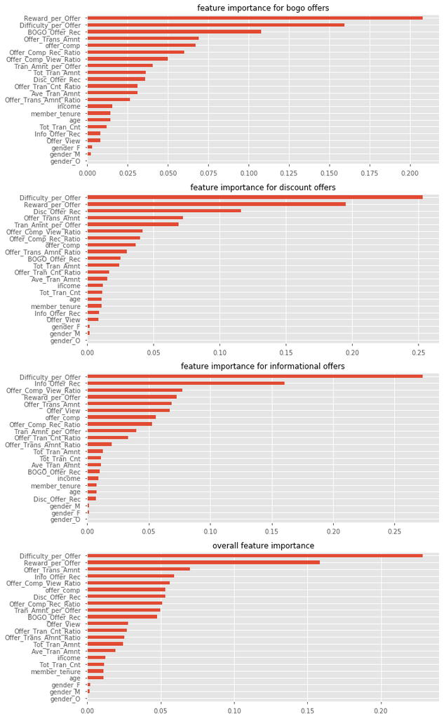

```python
plt.figure(figsize=(10,20))

plt.subplot(4,1,1)
feature_importance_rf = pd.Series(clf.estimators_[0].feature_importances_, index = x_train.columns).sort_values(ascending = True)
feature_importance_rf.plot.barh()
#plt.yticks(fontsize = 10)
plt.title('feature importance for bogo offers')

plt.subplot(4,1,2)
feature_importance_rf = pd.Series(clf.estimators_[1].feature_importances_, index = x_train.columns).sort_values(ascending = True)
feature_importance_rf.plot.barh()
#plt.yticks(fontsize = 10)
plt.title('feature importance for discount offers')

plt.subplot(4,1,3)
feature_importance_rf = pd.Series(clf.estimators_[2].feature_importances_, index = x_train.columns).sort_values(ascending = True)
feature_importance_rf.plot.barh()
#plt.yticks(fontsize = 10)
plt.title('feature importance for informational offers')

# overall
feat_impts = []
for mod in clf.estimators_:
    feat_impts.append(mod.feature_importances_)

plt.subplot(4,1,4)
feature_importance_rf = pd.Series(np.mean(feat_impts, axis=0), index = x_train.columns).sort_values(ascending = True)
feature_importance_rf.plot.barh()
#plt.yticks(fontsize = 10)
plt.title('overall feature importance')
```

It seems that `reward_per_offer`, `difficulty_per_offer` and `offer_trans_amt` are the most important features across the board. How is each feature different among the three offer types?

#### Feature Difference by Offer Combination

```
Text(0.5,1,'Metric Average of Offer Type Combinations')
```

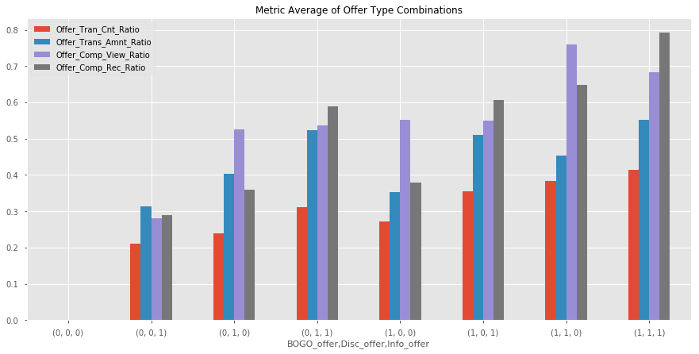

```python
user_data_final['Tran_Amnt_No_Offer'] = user_data_final['Tot_Tran_Amnt']- user_data_final['Offer_Trans_Amnt']
user_data_final['Trans_Cnt_No_Offer'] = user_data_final['Tot_Tran_Cnt']- user_data_final['offer_comp']

col_list1 = ['Offer_Tran_Cnt_Ratio', 'Offer_Trans_Amnt_Ratio', 'Offer_Comp_View_Ratio',
       'Offer_Comp_Rec_Ratio']
col_list2 = ['offer_comp', 'Tot_Tran_Cnt', 'Trans_Cnt_No_Offer', 'Tot_Rewards_Rec', 'Reward_per_Offer','Difficulty_per_Offer']
col_list3 = [ 'Tot_Tran_Amnt',  'Offer_Trans_Amnt',  'Tran_Amnt_per_Offer','Ave_Tran_Amnt', 'Tran_Amnt_No_Offer']
user_data_final[['BOGO_offer','Disc_offer','Info_offer']] = \
            user_data_final[['BOGO_offer','Disc_offer','Info_offer']].astype(int)

def mean_by_offer_type (data, columns):
    col = columns[0]
    df = data.groupby(['BOGO_offer','Disc_offer','Info_offer'])[col].mean().reset_index()
    for col in columns[1:]:
        curr = data.groupby(['BOGO_offer','Disc_offer','Info_offer'])[col].mean().reset_index()
        df = df.merge(curr, on =['BOGO_offer','Disc_offer','Info_offer'])
    return df

ratio_df = mean_by_offer_type (user_data_final, col_list1)

ratio_df.set_index(['BOGO_offer','Disc_offer','Info_offer']).plot.bar(figsize=(15,7), rot = 0)
plt.title('Metric Average of Offer Type Combinations')
```

```
Text(0.5,1,'Metric Average of Offer Type Combinations')
```

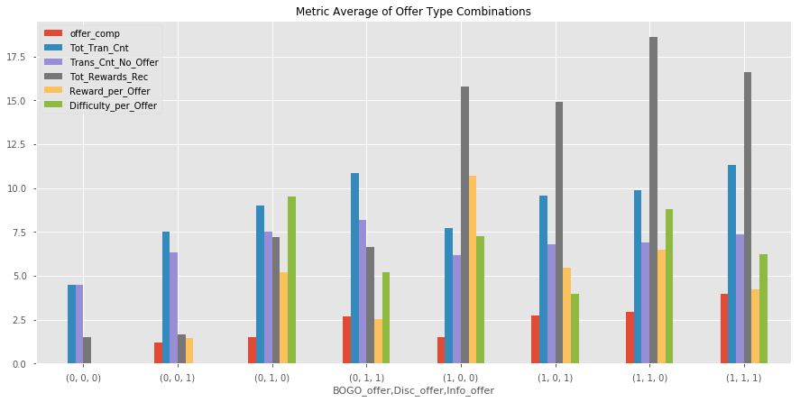

```python
trans_df = mean_by_offer_type (user_data_final, col_list2)

trans_df.set_index(['BOGO_offer','Disc_offer','Info_offer']).plot.bar(figsize=(15,7), rot = 0)
plt.title('Metric Average of Offer Type Combinations')
```

```
Text(0.5,1,'Metric Average of Offer Type Combinations')
```

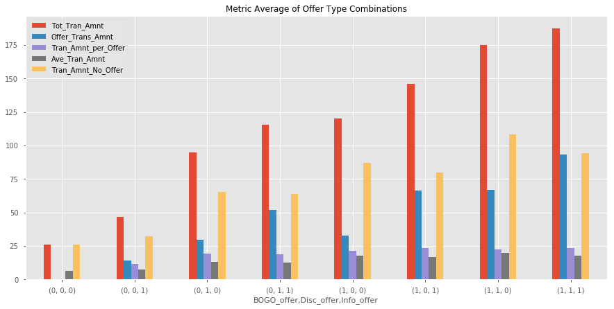

```python
trans_df = mean_by_offer_type (user_data_final, col_list3)

trans_df.set_index(['BOGO_offer','Disc_offer','Info_offer']).plot.bar(figsize=(15,7), rot = 0)
plt.title('Metric Average of Offer Type Combinations')
```

The labels on the X axis correspond to the three offer types respectively. When it's 1, it means people who use that offer type. eg. (1,1,0) means people who respond to bogo and discount offers but not informational offers.

It's apparent that people who use all three offer types not only spend the most with offers but also have the highest total transaction amount. It means the more we motivate the customers to use the offer, the more likely they spend more in store.

Also BOGO offer drives more sales than discount and informational offers in general since the right three groups with higher total transaction amount all have responded to bogo offer. It's also worth noting that people who uses bogo and discount offers actually spend more than half of the total transaction amount without offers. Those are Starbuck's most active and valuable customers. It is a positive sign to prove that giving our offers with rewards can indeed improve customers' engagement and as a result, drive sales overall.

Now let's take a look at how the overall offer completion rate, transaction amount ratio motivated by offer, and reward per offer affected by the user demographics.

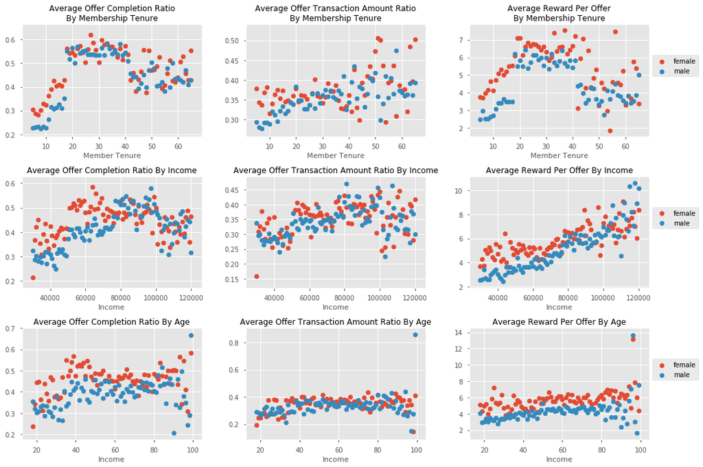

```python
plt.figure(figsize=(15,10))
plt.subplot(3,3,1)
female_avg = user_data_final[user_data_final.gender_F==1].groupby('member_tenure').mean()['Offer_Comp_Rec_Ratio']
male_avg = user_data_final[user_data_final.gender_M==1].groupby('member_tenure').mean()['Offer_Comp_Rec_Ratio']
plt.scatter(female_avg.index, female_avg);
plt.scatter(male_avg.index, male_avg);
plt.xlabel('Member Tenure');
plt.title('Average Offer Completion Ratio\nBy Membership Tenure')

plt.subplot(3,3,2)
female_avg = user_data_final[user_data_final.gender_F==1].groupby('member_tenure')['Offer_Trans_Amnt_Ratio'].mean()
male_avg = user_data_final[user_data_final.gender_M==1].groupby('member_tenure')['Offer_Trans_Amnt_Ratio'].mean()
plt.scatter(female_avg.index, female_avg);
plt.scatter(male_avg.index, male_avg);
plt.xlabel('Member Tenure');
plt.title('Average Offer Transaction Amount Ratio\nBy Membership Tenure')


plt.subplot(3,3,3)
female_avg = user_data_final[user_data_final.gender_F==1].groupby('member_tenure')['Reward_per_Offer'].mean()
male_avg = user_data_final[user_data_final.gender_M==1].groupby('member_tenure')['Reward_per_Offer'].mean()
plt.scatter(female_avg.index, female_avg);
plt.scatter(male_avg.index, male_avg);
plt.xlabel('Member Tenure');
plt.title('Average Reward Per Offer\nBy Membership Tenure')
plt.legend(['female', 'male'], bbox_to_anchor=(1.00, 0.5), loc=3);

plt.subplot(3,3,4)
female_avg = user_data_final[user_data_final.gender_F==1].groupby('income').mean()['Offer_Comp_Rec_Ratio']
male_avg = user_data_final[user_data_final.gender_M==1].groupby('income').mean()['Offer_Comp_Rec_Ratio']
plt.scatter(female_avg.index, female_avg);
plt.scatter(male_avg.index, male_avg);
plt.xlabel('Income');
plt.title('Average Offer Completion Ratio By Income')

plt.subplot(3,3,5)
female_avg = user_data_final[user_data_final.gender_F==1].groupby('income')['Offer_Trans_Amnt_Ratio'].mean()
male_avg = user_data_final[user_data_final.gender_M==1].groupby('income')['Offer_Trans_Amnt_Ratio'].mean()
plt.scatter(female_avg.index, female_avg);
plt.scatter(male_avg.index, male_avg);
plt.xlabel('Income');
plt.title('Average Offer Transaction Amount Ratio By Income')


plt.subplot(3,3,6)
female_avg = user_data_final[user_data_final.gender_F==1].groupby('income')['Reward_per_Offer'].mean()
male_avg = user_data_final[user_data_final.gender_M==1].groupby('income')['Reward_per_Offer'].mean()
plt.scatter(female_avg.index, female_avg);
plt.scatter(male_avg.index, male_avg);
plt.xlabel('Income');
plt.title('Average Reward Per Offer By Income')
plt.legend(['female', 'male'], bbox_to_anchor=(1.00, 0.5), loc=3);


plt.subplot(3,3,7)
female_avg = user_data_final[user_data_final.gender_F==1].groupby('age').mean()['Offer_Comp_Rec_Ratio']
male_avg = user_data_final[user_data_final.gender_M==1].groupby('age').mean()['Offer_Comp_Rec_Ratio']
plt.scatter(female_avg.index, female_avg);
plt.scatter(male_avg.index, male_avg);
plt.xlabel('Income');
plt.title('Average Offer Completion Ratio By Age')

plt.subplot(3,3,8)
female_avg = user_data_final[user_data_final.gender_F==1].groupby('age')['Offer_Trans_Amnt_Ratio'].mean()
male_avg = user_data_final[user_data_final.gender_M==1].groupby('age')['Offer_Trans_Amnt_Ratio'].mean()
plt.scatter(female_avg.index, female_avg);
plt.scatter(male_avg.index, male_avg);
plt.xlabel('Income');
plt.title('Average Offer Transaction Amount Ratio By Age')


plt.subplot(3,3,9)
female_avg = user_data_final[user_data_final.gender_F==1].groupby('age')['Reward_per_Offer'].mean()
male_avg = user_data_final[user_data_final.gender_M==1].groupby('age')['Reward_per_Offer'].mean()
plt.scatter(female_avg.index, female_avg);
plt.scatter(male_avg.index, male_avg);
plt.xlabel('Income');
plt.title('Average Reward Per Offer By Age')
plt.legend(['female', 'male'], bbox_to_anchor=(1.00, 0.5), loc=3);

plt.tight_layout()
```

Key takeaways from the scatter plots above:

1. Offer completion rate grows steadily as the tenure increases in the beginning, and is at its peak when the user tenures of both gender are between 20-30 months, then it declines a bit as the tenure increase, especially for male customers. In reality, the offer conversion rate would grow as the new users get used to the app and start utilizing the benefits more oftenm. After that phase, the conversion rate becomes plateaued.
2. Offer completion rate also seem to have a positive linear relationship with income before income hits 80000. After that it starts to drop as the income increases. Customers are more inclined to use offers when their incomes are below a certain level. After surpassing that income level, the effect of using an offer on motivating transactions decreases.
3. In general, female customers have a higher offer completion rate than male customers, especially in the early tenure and lower income bucket.
4. Average rewards per offer grows steadily as income increases.
5. Female customers also tend to earn higher rewards per offer across almost the whole spectrum of tenure, age and income. It is partly because females have a higher offer completion rate than males. It also implicates that female users are more prone to use BOGO or discount offers to earn rewards, since informational offer do not give out rewards.

Next I want to check whether different demographic groups respond differently to the three offer types.

```python
user_data_final['BOGO_Conv_Rate'] = user_data_final['BOGO_comp']/user_data_final['BOGO_Offer_Rec']
user_data_final['Disc_Conv_Rate'] = user_data_final['Disc_comp']/user_data_final['Disc_Offer_Rec']
user_data_final['Info_Conv_Rate'] = user_data_final['Info_comp']/user_data_final['Info_Offer_Rec']
```

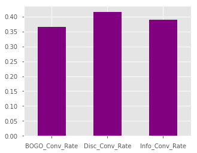

```python
plt.figure(figsize=(5,4))
user_data_final[['BOGO_Conv_Rate', 'Disc_Conv_Rate', 'Info_Conv_Rate']].mean().plot.bar(color='Purple',rot=0)
```

Discount offer has a slightly higher average conversion rate than the other two offer types, making it the most effective offer among three.

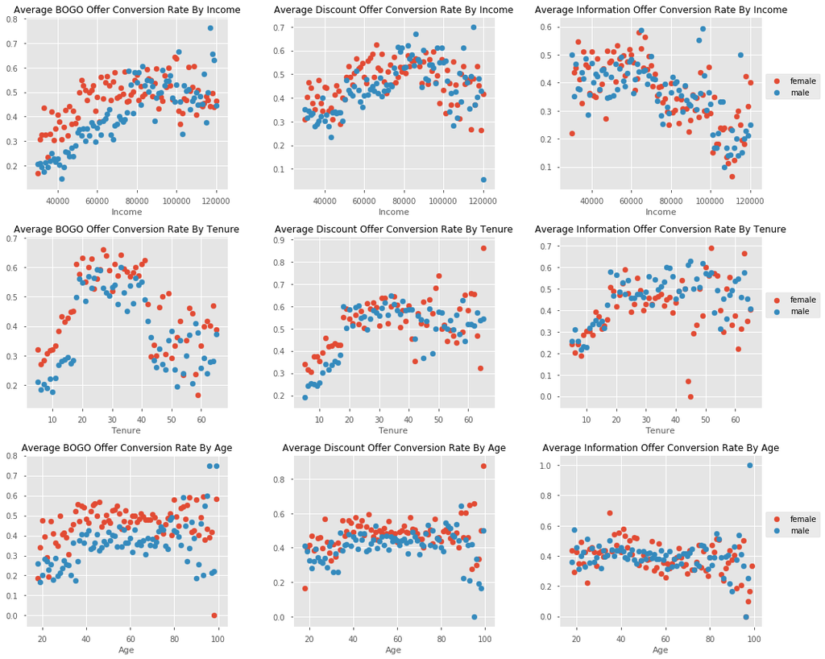

```python
plt.style.use('seaborn-notebook')
plt.figure(figsize=(15, 12))
plt.subplot(3,3,1)
female_avg = user_data_final[user_data_final.gender_F==1].groupby('income')['BOGO_Conv_Rate'].mean()
male_avg = user_data_final[user_data_final.gender_M==1].groupby('income')['BOGO_Conv_Rate'].mean()
plt.scatter(female_avg.index, female_avg);
plt.scatter(male_avg.index, male_avg);
plt.xlabel('Income');
plt.title('Average BOGO Offer Conversion Rate By Income')

plt.subplot(3,3,2)
female_avg = user_data_final[user_data_final.gender_F==1].groupby('income')['Disc_Conv_Rate'].mean()
male_avg = user_data_final[user_data_final.gender_M==1].groupby('income')['Disc_Conv_Rate'].mean()
plt.scatter(female_avg.index, female_avg);
plt.scatter(male_avg.index, male_avg);
plt.xlabel('Income');
plt.title('Average Discount Offer Conversion Rate By Income')

plt.subplot(3,3,3)
female_avg = user_data_final[user_data_final.gender_F==1].groupby('income')['Info_Conv_Rate'].mean()
male_avg = user_data_final[user_data_final.gender_M==1].groupby('income')['Info_Conv_Rate'].mean()
plt.scatter(female_avg.index, female_avg);
plt.scatter(male_avg.index, male_avg);
plt.xlabel('Income');
plt.title('Average Information Offer Conversion Rate By Income')
plt.legend(['female', 'male'], bbox_to_anchor=(1.00, 0.5), loc=3);

plt.subplot(3,3,4)
female_avg = user_data_final[user_data_final.gender_F==1].groupby('member_tenure')['BOGO_Conv_Rate'].mean()
male_avg = user_data_final[user_data_final.gender_M==1].groupby('member_tenure')['BOGO_Conv_Rate'].mean()
plt.scatter(female_avg.index, female_avg);
plt.scatter(male_avg.index, male_avg);
plt.xlabel('Tenure');
plt.title('Average BOGO Offer Conversion Rate By Tenure')

plt.subplot(3,3,5)
female_avg = user_data_final[user_data_final.gender_F==1].groupby('member_tenure')['Disc_Conv_Rate'].mean()
male_avg = user_data_final[user_data_final.gender_M==1].groupby('member_tenure')['Disc_Conv_Rate'].mean()
plt.scatter(female_avg.index, female_avg);
plt.scatter(male_avg.index, male_avg);
plt.xlabel('Tenure');
plt.title('Average Discount Offer Conversion Rate By Tenure')

plt.subplot(3,3,6)
female_avg = user_data_final[user_data_final.gender_F==1].groupby('member_tenure')['Info_Conv_Rate'].mean()
male_avg = user_data_final[user_data_final.gender_M==1].groupby('member_tenure')['Info_Conv_Rate'].mean()
plt.scatter(female_avg.index, female_avg);
plt.scatter(male_avg.index, male_avg);
plt.xlabel('Tenure');
plt.title('Average Information Offer Conversion Rate By Tenure')
plt.legend(['female', 'male'], bbox_to_anchor=(1.00, 0.5), loc=3);

plt.subplot(3,3,7)
female_avg = user_data_final[user_data_final.gender_F==1].groupby('age')['BOGO_Conv_Rate'].mean()
male_avg = user_data_final[user_data_final.gender_M==1].groupby('age')['BOGO_Conv_Rate'].mean()
plt.scatter(female_avg.index, female_avg);
plt.scatter(male_avg.index, male_avg);
plt.xlabel('Age');
plt.title('Average BOGO Offer Conversion Rate By Age')

plt.subplot(3,3,8)
female_avg = user_data_final[user_data_final.gender_F==1].groupby('age')['Disc_Conv_Rate'].mean()
male_avg = user_data_final[user_data_final.gender_M==1].groupby('age')['Disc_Conv_Rate'].mean()
plt.scatter(female_avg.index, female_avg);
plt.scatter(male_avg.index, male_avg);
plt.xlabel('Age');
plt.title('Average Discount Offer Conversion Rate By Age')

plt.subplot(3,3,9)
female_avg = user_data_final[user_data_final.gender_F==1].groupby('age')['Info_Conv_Rate'].mean()
male_avg = user_data_final[user_data_final.gender_M==1].groupby('age')['Info_Conv_Rate'].mean()
plt.scatter(female_avg.index, female_avg);
plt.scatter(male_avg.index, male_avg);
plt.xlabel('Age');
plt.title('Average Information Offer Conversion Rate By Age')
plt.legend(['female', 'male'], bbox_to_anchor=(1.00, 0.5), loc=3);

plt.tight_layout()
```

There are couple interesting insights from this set of scatter plots.